# 10-Factor Portfolio Risk & Tail Estimation

Evaluating Parameter Uncertainty in Expected Returns Against Analytical Benchmarks

### Introduction

This chapter transitions from two-dimensional toy mechanics to a multi-asset portfolio comprising ten correlated risk factor exposures—spanning core equity betas, corporate credit carry, duration hedges, and commodities.

To provide a mathematically rigorous audit baseline, we formulate a Bayesian return model with a known closed-form solution. We model daily returns as multivariate normal $\mathbf{R} \sim \mathcal{N}(\boldsymbol{\mu}, \mathbf{\Sigma})$ with a diffuse Gaussian prior on the mean vector $\boldsymbol{\mu} \sim \mathcal{N}(\mathbf{0}, 10^3 \mathbf{I})$ and condition the covariance matrix on the empirical sample estimate $\mathbf{\Sigma} = \hat{\mathbf{\Sigma}}_{\text{emp}}$. Under this conjugate structure, the joint posterior distribution of expected returns is analytically known:
$$\boldsymbol{\mu} \mid \mathbf{R}, \mathbf{\Sigma} \sim \mathcal{N}\left(\bar{\mathbf{x}}, \frac{1}{n} \mathbf{\Sigma}\right)$$

While a closed-form solution exists for this specific Gaussian model, using it as our target allows us to directly benchmark MCMC performance. We can compare the empirical draws, standard errors, and credible intervals from our first-principles Metropolis sampler directly against the analytical truth.

```r
knitr::opts_chunk$set(echo = TRUE, message = FALSE, warning = FALSE)

library(dplyr)
library(gt)
library(scales)
library(ggplot2)

source("R/metropolis_sampler.R")
source("R/risk_functions.R")
source("R/plots.R")

# 1. Ingest synthetic book fixture and build log-posterior
model_fixture <- build_risk_target("data/synthetic_returns.csv")

# 2. Run 10-dimensional MCMC chain
init_theta <- rep(0, model_fixture$d)
names(init_theta) <- model_fixture$asset_names

chain_10d <- run_metropolis(
  target_log_posterior = model_fixture$target_fn,
  initial_theta = init_theta,
  iterations = 3000,
  proposal_sd = 0.00032,
  seed = 42
)

# 3. Discard first 500 draws as burn-in
post_burn_draws <- chain_10d$draws %>% slice_tail(n = 2500)

# 4. Tail risk evaluation across equal-weighted portfolio
weights_eq <- rep(0.10, 10)
risk_table <- evaluate_portfolio_tail_risk(
  draws_df = post_burn_draws,
  weights = weights_eq,
  cov_mat = model_fixture$cov_emp,
  alpha = 0.95
)

# 5. Pre-formatted text variables for dynamic inline reporting
acc_rate_txt   <- sprintf("%.1f%%", chain_10d$acceptance_rate * 100)
var_mean_txt   <- sprintf("%.2f%%", risk_table$mean_estimate[1] * 100)
var_ci_txt     <- sprintf("[%.2f%%, %.2f%%]", risk_table$ci_05[1] * 100, risk_table$ci_95[1] * 100)
es_mean_txt    <- sprintf("%.2f%%", risk_table$mean_estimate[2] * 100)
es_ci_txt      <- sprintf("[%.2f%%, %.2f%%]", risk_table$ci_05[2] * 100, risk_table$ci_95[2] * 100)
n_draws_txt    <- comma(nrow(post_burn_draws))
```

### Sampling the 10-Factor Joint Posterior

The sampler processes 250 trading days of observed returns across all 10 assets simultaneously. Starting cold at $\boldsymbol{\mu}_0 = \mathbf{0}$, the chain completes 3,000 iterations, discarding the first 500 iterations to eliminate initialization bias. The chain operates at an empirical acceptance rate of 28.9%.

```r
risk_table %>%
  gt() %>%
  tab_header(
    title = md("**10-Asset Portfolio Tail Risk Estimates (1-Day Horizon)**"),
    subtitle = "Posterior mean risk metrics and 90% Bayesian credible intervals under parameter uncertainty"
  ) %>%
  cols_label(
    metric = "Tail Risk Measure",
    mean_estimate = "Posterior Mean",
    ci_05 = "5th Percentile",
    ci_95 = "95th Percentile"
  ) %>%
  fmt_percent(columns = c(mean_estimate, ci_05, ci_95), decimals = 2) %>%
  tab_options(table.font.size = 12)
```

**10-Asset Portfolio Tail Risk Estimates (1-Day Horizon)**

Posterior mean risk metrics and 90% Bayesian credible intervals under parameter uncertainty

| Tail Risk Measure | Posterior Mean | 5th Percentile | 95th Percentile |
| --- | --- | --- | --- |
| VaR (95%) | 1.05% | 0.99% | 1.11% |
| Expected Shortfall (95%) | 1.33% | 1.27% | 1.39% |

#### Context: Isolating Parameter Risk in the Mean Vector

Because the return distribution is modeled as multivariate normal and $\mathbf{\Sigma}$ is fixed at the sample estimate, the portfolio tail metrics reflect the properties of Gaussian loss distributions under estimation uncertainty:

1. **Mean Uncertainty Bounds ($\text{VaR}_{95\%}$):** For an equal-weighted portfolio, parametric Value at Risk is governed by $\text{VaR}_{95\%} \approx -\mathbf{w}'\boldsymbol{\mu} + 1.645 \cdot \sigma_p$. Because covariance is held constant, the 12 basis point spread between the 5th and 95th percentiles ($0.99\%$ to $1.11\%$) reflects the estimation uncertainty of the portfolio mean alone ($\pm 1.645 \cdot \sigma_p / \sqrt{n}$), setting aside covariance uncertainty.
2. **Expected Shortfall Ratio ($\text{ES}_{95\%}$):** The ratio of Expected Shortfall to Value at Risk ($1.33\% / 1.05\% \approx 1.27$ ) reflects standard Gaussian tail expectation constants ($\approx 2.063 / 1.645$), adjusted for the portfolio drift. Under a normal likelihood, this metric captures linear downside expectation rather than excess kurtosis or heavy-tailed structural shocks.

### Benchmarking MCMC Against the Exact Posterior

Table 1

**Tail Risk: MCMC vs. Exact Posterior**

Equal-weighted portfolio, 1-day horizon

| Metric | MCMC | Exact |
| --- | --- | --- |
| VaR 95% — mean | 1.046% | 1.051% |
| VaR 95% — 90% interval | 0.99% – 1.11% | 0.98% – 1.12% |
| ES 95% — mean | 1.329% | 1.334% |
| ES 95% — 90% interval | 1.27% – 1.39% | 1.26% – 1.40% |

Table 2

**Per-Factor Posterior: MCMC vs. Exact**

Daily expected returns; SD Ratio < 1 means MCMC under-disperses

| Factor | MCMC Mean | Exact Mean | MCMC SD | Exact SD | SD Ratio | Mean Error (SDs) |
| --- | --- | --- | --- | --- | --- | --- |
| US_LargeCap | 0.177% | 0.174% | 0.053% | 0.063% | 0.84 | 0.05 |
| US_SmallCap | 0.122% | 0.126% | 0.081% | 0.092% | 0.88 | −0.04 |
| Tech_Growth | 0.338% | 0.323% | 0.091% | 0.101% | 0.90 | 0.14 |
| EU_Equity | 0.044% | 0.041% | 0.059% | 0.072% | 0.82 | 0.03 |
| EM_Equity | 0.228% | 0.226% | 0.083% | 0.095% | 0.87 | 0.02 |
| US_Treas_10Y | −0.022% | −0.021% | 0.030% | 0.031% | 0.97 | −0.03 |
| US_Corp_Credit | −0.045% | −0.049% | 0.036% | 0.040% | 0.91 | 0.10 |
| Commodities | −0.066% | −0.071% | 0.072% | 0.082% | 0.89 | 0.06 |
| Gold | −0.055% | −0.057% | 0.067% | 0.062% | 1.08 | 0.03 |
| Real_Estate | −0.037% | −0.056% | 0.070% | 0.077% | 0.91 | 0.25 |

### What the Benchmark Shows

The MCMC point estimates match the exact posterior: portfolio VaR and ES means agree to the second decimal place. The **credible intervals** are narrower than they should be. The MCMC VaR interval is about 83% of the exact width, so the sampler understates parameter uncertainty.

Nine of ten factors under-disperse (SD ratio 0.82–0.97). The pattern is broad-based rather than concentrated in the lowest-ESS factors, consistent with chains that have explored only part of the posterior.

**Implication for risk reporting:** a poorly mixed sampler can report the right central estimate while producing credible intervals that are too narrow, which understates parameter risk. Without a closed-form benchmark or proper diagnostics, this failure would go unnoticed.

**Parameter Distributions vs. Generative Ground Truth**

Because the fixture was simulated from known parameters, we can compare the sampled MCMC distributions against both the generative population values and the analytical sample estimates.

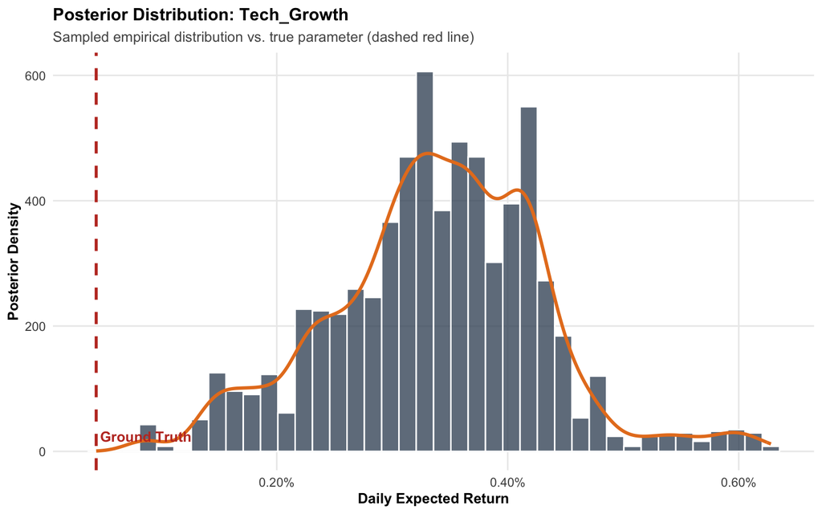

Figure 1: Marginal posterior distribution for Tech Growth expected daily returns.

```r
plot_posterior_marginals(
  draws_df = post_burn_draws,
  asset_name = "Tech_Growth",
  true_val = 0.110 / 252
)
```

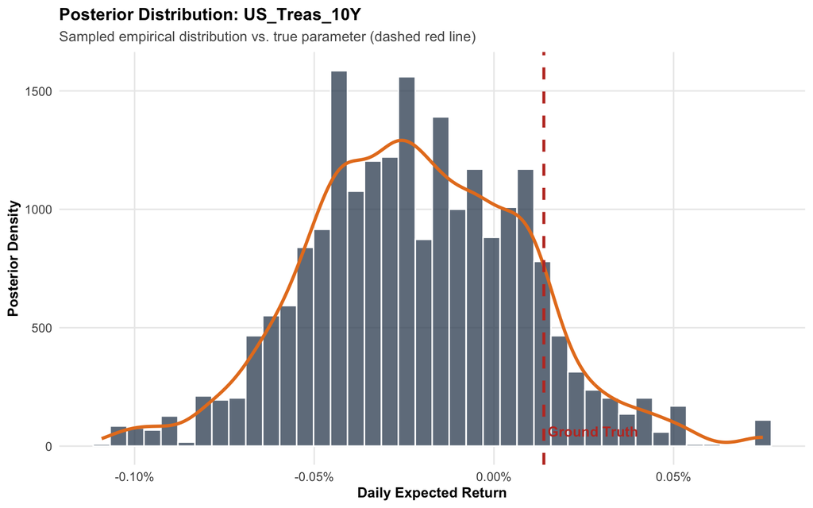

Figure 2: Marginal posterior distribution for 10Y US Treasury returns(Duration hedge).

```r
plot_posterior_marginals(
  draws_df = post_burn_draws,
  asset_name = "US_Treas_10Y",
  true_val = 0.035 / 252
)
```

**Understanding the Marginal Density Plots**

**Tech Growth:** The posterior centers on the sample mean, approximately 0.34% daily, with a posterior standard deviation of about 0.10%. The 90% credible interval runs from +0.17% to +0.47%. The true value used to generate the data, +0.044% daily (+11.0% annualized), lies about 2.8 posterior standard deviations below the center.

This is not a sampler error. By chance, this 250-day sample shows a Tech Growth drift of roughly 82% annualized. The posterior correctly reports what the data support; the data simply don’t support the true value.

**US Treasuries (10Y):** The posterior centers near -0.02% daily, with a standard deviation of about 0.03% and a 90% credible interval of -0.07% to +0.03%. The true value (+0.014% daily) lies about 1.1 standard deviations from the center.

Narrowing Tech Growth’s uncertainty to 0.01% daily would take about 25,451 trading days of data.

**ImportantKey Takeaway: Parameter Recovery Is a Data Problem, Not a Sampler Problem**

MCMC recovers the **posterior**, not the **truth**. With 250 daily observations, mean returns are poorly identified: Tech Growth’s posterior standard deviation (≈0.10% daily) is more than twice its true mean. Narrowing that uncertainty to about 0.01% daily would take roughly 25,451 trading days of data. For risk managers, a year of history can’t reliably tell a high-drift asset from a low-drift one. That estimation uncertainty is exactly what the VaR and ES credible intervals are meant to capture.